# 🚀 Submission Instructions: Export Notebook to HTML

You must submit your work as an **HTML file** (not `.ipynb`).  
Follow the steps below depending on whether you worked in **Jupyter Notebook** or **Google Colab**.

## 🔹 If you used **Jupyter Notebook (Anaconda / local Jupyter)**

1. Open your completed `.ipynb` file.
2. In the menu bar, click **File → Download as → HTML (.html)**.
3. This will save an `.html` file to your computer.
4. Open the `.html` file in a web browser to check that all code, outputs, and plots are visible.
5. Submit the `.html` file on the course portal.

## 🔹 If you used **Google Colab**

1. Open your completed Colab notebook.
2. Dowload the .ipynb and follow https://plainenglish.io/blog/how-to-convert-google-colab-notebook-ipynb-to-html-ccfeda199246

OR

Simply download the .ipynb file and open on Jupyter to save it as HTML.

## ✅ Final Checklist

- File extension is **.html** (not `.ipynb` or `.pdf`).
- All **code, outputs, and plots** are visible.
- The file opens correctly in a browser (Chrome/Edge/Firefox).

```python
from google.colab import drive
drive.mount('/content/drive')
```

```python
!jupyter nbconvert --to html "/content/MLP_CS461 (1).ipynb"
```

```
[NbConvertApp] Converting notebook /content/MLP_CS461 (1).ipynb to html
[NbConvertApp] WARNING | Alternative text is missing on 11 image(s).
[NbConvertApp] Writing 880509 bytes to /content/MLP_CS461 (1).html
```

# MENTION YOUR NAME AND NETID IN THIS BOX

# Oluwanifemi Kayode-Alese, ook9

# 📘 MLP Assignment 01

## Part A — Conceptual Questions (Multiple answers to the same question is allowed. Give a one line explanation for each)

### Q1. Movie Review Sentiment Analysis (5 pts)

A dataset contains text reviews of movies that are labeled as positive or negative.

**Which ML approach would you use?**  
Choices: Logistic Regression, Naïve Bayes, K-Means, Linear Regression

### Q2. Customer Segmentation

A dataset records information about 10,000 mall customers, including age, annual income, and spending score.  
The business wants to group similar customers together for targeted marketing.

**Which ML approach would you use?**  
Choices: Logistic Regression, KNN, Naïve Bayes, K-Means, Linear Regression

### Q3. Spam Detection

You have a dataset of emails that are labeled as spam or not spam, each represented as a bag-of-words vector.

**Which ML approach would you use?**  
Choices: Naïve Bayes, Decision Tree, Logistic Regression, K-Means, Linear Regression

### Q4. Image Classification

You are given a dataset of handwritten digit images (0–9), where each image is represented by pixel intensity values.  
The goal is to predict the digit label for a new image.

**Which ML approach would you use?**  
Choices: Logistic Regression, KNN, Naïve Bayes, K-Means, Linear Regression

### Conceptual Question

KNN, Decision Trees, Naïve Bayes, and K-Means all use very different ideas to make predictions or find structure.  
**Briefly explain how each of these algorithms decides a label (or grouping) in one or two sentences each.**

- **KNN:**
- **Decision Trees:**
- **Naïve Bayes:**
- **K-Means:**

WRITE ANSWERS HERE

Q1. Movie Review Sentiment Analysis (5 pts)

Answer: Since the result is either positive or negative, that means that this is a binary classification. Therefore, we can use:

- **Logistic Regression**: it is a supervised classification as the results are known, and it will predict a binary outcome based on the features
- **Naïve Bayes**: This can also be used for the text classification if it assumes word independence and it performs well on bag-of-words models assuming this uses bag-of-word vectors.

Q2. Customer Segmentation

Answer: This is an unsupervised learning algorithm, and we will be need to perform clustering for similar customers therefore **K-Means** can be used. It can group customers based on the similarity in features like annual income, spending score, etc.

Q3. Spam Detection Answer:

Answer: Since the result is either spam or not spam, that means that this is a binary classification. Therefore, we can use:

- **Logistic Regression**: it is a supervised classification as the results are known, and it will predict a binary outcome based on the features
- **Naïve Bayes**: This can also be used for the text classification if it assumes word independence and it performs well on bag-of-words models since it is noted that each one is represented as a bag-of-words vector

Q4. Image Classification

Answer: Since this is a dataset of digit images, represnted by intensity vales, we can:

- **KNN** : predict the digit label of a new image based on the majority label of its nearest neighbors.
- **Logistic Regression** : classify the images into multiple classes (digits 0-9) after we learn the linear decision boundaries.

Conceptual Question

**KNN**: Does classification by finding the k nearest neighbors and assigning the most common label among them.

**Decision Trees**: Recursively splits data based on feature thresholds that can maximize information gain, forming a tree where each leaf represents a class label.

**Naïve Bayes**: Uses Bayes' theorem with the assumption that features are independent, assigning the label with the highest posterior probability given the feature values.

**K-Means**: splits the data into k clusters by assigning each point to the nearest cluster centroid and iteratively updating centroids to minimize within-cluster variance.

PART 1

# 📝 KNN on Digits Dataset

**Dataset:** `sklearn.datasets.load_digits()`

- 1,797 grayscale digit images (8×8)
- 64 numeric features
- 10 classes (digits 0–9)

**Allowed Libraries:** `numpy`, `pandas`, `matplotlib`, `scikit-learn` (Only for data loading, metrics, and train/val/test splits — *not* for KNN itself)

**Random Seed:** 42 **Splits:** Stratified

## 🔹 Step 1 — Load & Split

- Load the digits dataset.
- Split into:
  - 60% **train**
  - 20% **validation**
  - 20% **test** (Use stratified splits to preserve class distribution.)
- Print shapes of each split.
- Create a small table of **class counts per split** (no overlap).

**Deliverable:** 📊 Table showing per-class counts for train, validation, and test sets.

## 🔹 Step 2 — Implement KNN (from scratch)

- Implement **KNN classifier** manually:
  - Distance metric: **Euclidean distance**
  - Neighbor votes: **majority vote**
- Try values of `k ∈ {1, 3, 5, 7, 9, 11, 15}`.
- Train on **train**, evaluate on **validation**.
- Plot **accuracy vs. k** (line chart).
- Select the **best k** (ties broken by smaller k).

**Deliverable:**

- 📈 Accuracy vs. k plot

## 🔹 Step 3 — Final Test Evaluation

- Retrain on **train + validation** with the chosen k.
- On **test set**, report:
  - Accuracy
  - Macro-Precision, Macro-Recall, Macro-F1
  - Per-class Precision & Recall
  - Confusion Matrix (plot)
- Apply **standardization** using `sklearn.StandardScaler`.
- Compare results **before vs. after scaling**.

✅ **End Goal:** A complete notebook showing KNN built from scratch, evaluated on digits dataset, with clear plots, metrics, and short interpretations.

```python
import numpy as np
import pandas as pd
import matplotlib.pyplot as plt
from sklearn.datasets import load_digits
from sklearn.model_selection import train_test_split
from sklearn.preprocessing import StandardScaler
from sklearn.metrics import (
    accuracy_score, precision_recall_fscore_support, confusion_matrix, ConfusionMatrixDisplay
)


np.random.seed(42)
```

```python
digits = load_digits()
X = digits.data
y = digits.target

X_train, X_temp, y_train, y_temp = train_test_split(
    X, y, test_size=0.4, stratify=y, random_state=42
)
X_val, X_test, y_val, y_test = train_test_split(
    X_temp, y_temp, test_size=0.5, stratify=y_temp, random_state=42
)

# Shapes
print("Train:", X_train.shape, "Validation:", X_val.shape, "Test:", X_test.shape)
```

```
Train: (1078, 64) Validation: (359, 64) Test: (360, 64)
```

```python
def class_counts(y):
    counts = pd.Series(y).value_counts().sort_index()
    return counts

class_table = pd.DataFrame({
    "Train": class_counts(y_train),
    "Validation": class_counts(y_val),
    "Test": class_counts(y_test)
})
class_table
```

|  | Train | Validation | Test |
| --- | --- | --- | --- |
| 0 | 107 | 36 | 35 |
| 1 | 109 | 36 | 37 |
| 2 | 106 | 36 | 35 |
| 3 | 110 | 36 | 37 |
| 4 | 109 | 36 | 36 |
| 5 | 109 | 36 | 37 |
| 6 | 109 | 36 | 36 |
| 7 | 107 | 36 | 36 |
| 8 | 104 | 35 | 35 |
| 9 | 108 | 36 | 36 |

```python
def euclidean_distance(a, b):
    return np.sqrt(np.sum((a - b) ** 2, axis=1))
```

# You can add or remove code blocks wherever required throughout the assignment

```python
class KNN:
    def __init__(self, k=3):
        """
        Initialize KNN with a given number of neighbors (k).
        """
        self.k = k

    def fit(self, X, y):
        """
        Store the training data and labels.
        KNN is a lazy learner — it doesn't train a model,
        just remembers all training examples for future distance comparisons.
        """
        self.X_train = X
        self.y_train = y

    def predict(self, X):
        """
        Predict labels for each example in X.
        For each input sample:
          1. Compute distances to all training samples
          2. Identify the k nearest neighbors
          3. Use majority vote to assign the class
        Returns an array of predictions.
        """
        predictions = [self._predict(x) for x in X]
        return np.array(predictions)

    def _predict(self, x):
        """
        Predict label for a single example.
        Steps:
          1. Compute Euclidean distance between x and every training point
          2. Sort by distance and select the top-k indices
          3. Retrieve corresponding labels
          4. Perform majority voting among those labels
        Returns the most frequent label among nearest neighbors.
        """

        # Computing distances, sorting, picking top k with labels
        eu = euclidean_distance(self.X_train, x)
        k_idx = np.argsort(eu)[:self.k]
        k_labels = self.y_train[k_idx]
        # Majority vote
        vals, counts = np.unique(k_labels, return_counts=True)
        majority_vote = vals[np.argmax(counts)]

        return majority_vote
```

```python
k_values = [1, 3, 5, 7, 9, 11, 15]
val_accuracies = []

for k in k_values:
    model = KNN(k=k)
    model.fit(X_train, y_train)
    y_pred_val = model.predict(X_val)
    acc = accuracy_score(y_val, y_pred_val)
    val_accuracies.append(acc)
    print(f"K={k}, Validation Accuracy={acc:.4f}")
```

```
K=1, Validation Accuracy=0.9777
K=3, Validation Accuracy=0.9805
K=5, Validation Accuracy=0.9721
K=7, Validation Accuracy=0.9694
K=9, Validation Accuracy=0.9749
K=11, Validation Accuracy=0.9749
K=15, Validation Accuracy=0.9666
```

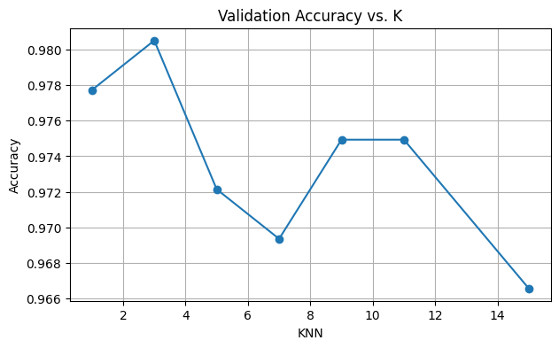

```
Best k = 3
```

```python
plt.figure(figsize=(7,4))
plt.plot(k_values, val_accuracies, marker='o', linestyle='-')
plt.title("Validation Accuracy vs. K")
plt.xlabel("KNN")
plt.ylabel("Accuracy")
plt.grid(True)
plt.show()

best_k = k_values[np.argmax(val_accuracies)]
print(f"Best k = {best_k}")
```

```python
X_combined = np.vstack([X_train, X_val])
y_combined = np.hstack([y_train, y_val])

final_model = KNN(k=best_k)
final_model.fit(X_combined, y_combined)
y_pred_test = final_model.predict(X_test)
```

```python
acc = accuracy_score(y_test, y_pred_test)
prec, rec, f1, _ = precision_recall_fscore_support(y_test, y_pred_test, average='macro')
print(f"Accuracy: {acc:.4f}")
print(f"Macro Precision: {prec:.4f}")
print(f"Macro Recall: {rec:.4f}")
print(f"Macro F1: {f1:.4f}")
```

```
Accuracy: 0.9833
Macro Precision: 0.9837
Macro Recall: 0.9831
Macro F1: 0.9832
```

```python
per_class = pd.DataFrame(
    precision_recall_fscore_support(y_test, y_pred_test, average=None)[:3],
    index=["Precision", "Recall","F1"],
    columns=np.unique(y_test)
).T
per_class
```

|  | Precision | Recall | F1 |
| --- | --- | --- | --- |
| 0 | 1.000000 | 0.971429 | 0.985507 |
| 1 | 0.947368 | 0.972973 | 0.960000 |
| 2 | 1.000000 | 1.000000 | 1.000000 |
| 3 | 0.973684 | 1.000000 | 0.986667 |
| 4 | 0.972973 | 1.000000 | 0.986301 |
| 5 | 0.973684 | 1.000000 | 0.986667 |
| 6 | 1.000000 | 1.000000 | 1.000000 |
| 7 | 1.000000 | 1.000000 | 1.000000 |
| 8 | 0.969697 | 0.914286 | 0.941176 |
| 9 | 1.000000 | 0.972222 | 0.985915 |

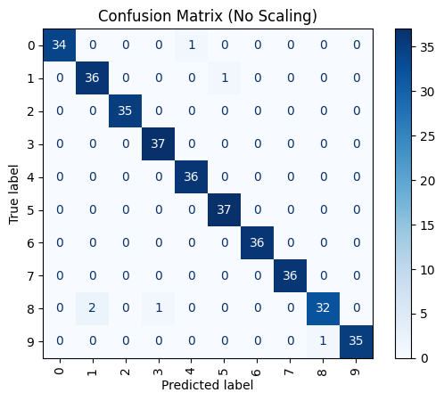

```python
cm = confusion_matrix(y_test, y_pred_test)
ConfusionMatrixDisplay(cm, display_labels=digits.target_names).plot(cmap='Blues', xticks_rotation='vertical')
plt.title("Confusion Matrix (No Scaling)")
plt.show()
```

```python
# Standardizing
scaler = StandardScaler()
X_train_s = scaler.fit_transform(X_train)
X_val_s = scaler.transform(X_val)
X_test_s = scaler.transform(X_test)

# Re-evaluating
val_accuracies_scaled = []
for k in k_values:
    model = KNN(k=k)
    model.fit(X_train_s, y_train)
    y_pred_val = model.predict(X_val_s)
    acc = accuracy_score(y_val, y_pred_val)
    val_accuracies_scaled.append(acc)
    print(f"K={k}, Validation Accuracy={acc:.4f}")
```

```
K=1, Validation Accuracy=0.9721
K=3, Validation Accuracy=0.9638
K=5, Validation Accuracy=0.9610
K=7, Validation Accuracy=0.9638
K=9, Validation Accuracy=0.9638
K=11, Validation Accuracy=0.9499
K=15, Validation Accuracy=0.9415
```

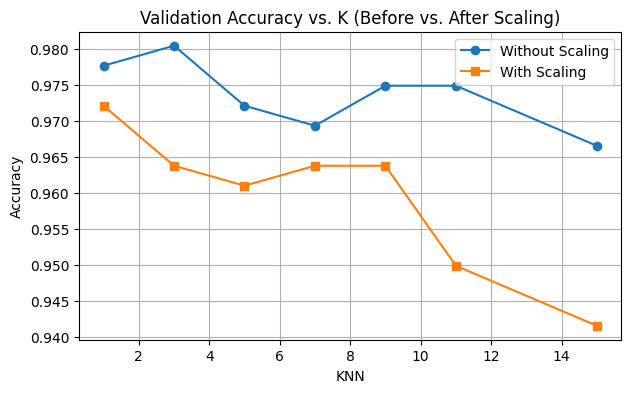

```python
plt.figure(figsize=(7,4))
plt.plot(k_values, val_accuracies, marker='o', label='Without Scaling')
plt.plot(k_values, val_accuracies_scaled, marker='s', label='With Scaling')
plt.title("Validation Accuracy vs. K (Before vs. After Scaling)")
plt.xlabel("KNN")
plt.ylabel("Accuracy")
plt.legend()
plt.grid(True)
plt.show()
```

```
Best k after scaling = 1
After Scaling: Accuracy: 0.9722
Macro Precision: 0.9724
Macro Recall: 0.9718
Macro F1: 0.9717
```

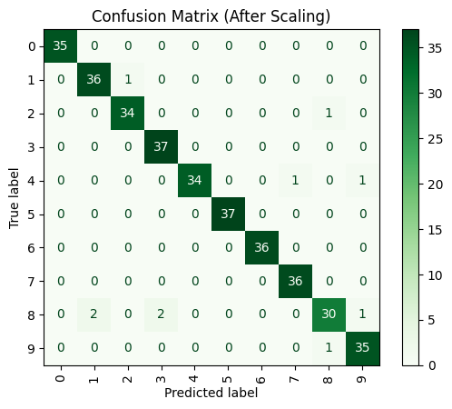

```python
best_k_scaled = k_values[np.argmax(val_accuracies_scaled)]
print(f"Best k after scaling = {best_k_scaled}")

X_combined_s = np.vstack([X_train_s, X_val_s])
y_combined_s = np.hstack([y_train, y_val])

final_scaled = KNN(k=best_k_scaled)
final_scaled.fit(X_combined_s, y_combined_s)
y_pred_test_s = final_scaled.predict(X_test_s)

acc_s = accuracy_score(y_test, y_pred_test_s)
prec_s, rec_s, f1_s, _ = precision_recall_fscore_support(y_test, y_pred_test_s, average='macro')

print(f"After Scaling: Accuracy: {acc_s:.4f}")
print(f"Macro Precision: {prec_s:.4f}")
print(f"Macro Recall: {rec_s:.4f}")
print(f"Macro F1: {f1_s:.4f}")

cm_s = confusion_matrix(y_test, y_pred_test_s)
ConfusionMatrixDisplay(cm_s, display_labels=digits.target_names).plot(cmap='Greens', xticks_rotation='vertical')
plt.title("Confusion Matrix (After Scaling)")
plt.show()
```

```python
per_class = pd.DataFrame(
    precision_recall_fscore_support(y_test, y_pred_test_s, average=None)[:3],
    index=["Precision", "Recall","F1"],
    columns=np.unique(y_test)
).T
per_class
```

|  | Precision | Recall | F1 |
| --- | --- | --- | --- |
| 0 | 1.000000 | 1.000000 | 1.000000 |
| 1 | 0.947368 | 0.972973 | 0.960000 |
| 2 | 0.971429 | 0.971429 | 0.971429 |
| 3 | 0.948718 | 1.000000 | 0.973684 |
| 4 | 1.000000 | 0.944444 | 0.971429 |
| 5 | 1.000000 | 1.000000 | 1.000000 |
| 6 | 1.000000 | 1.000000 | 1.000000 |
| 7 | 0.972973 | 1.000000 | 0.986301 |
| 8 | 0.937500 | 0.857143 | 0.895522 |
| 9 | 0.945946 | 0.972222 | 0.958904 |

**REFLECTION** Normally, scaling would improve KNN, since methods based on distances are sensitive to the magnitude of the feature. However, the case of this model, it was already performing near perfectly, so scaling did not add much instead it seems to have intoduced small noise effects

The change in optimal k from 3 to 1 also suggests the scaled distances became tighter, so the algorithm found fewer neighbors sufficient.

## Naïve Bayes on Heart Failure Prediction Dataset

## Dataset: Heart Failure Prediction (Kaggle/UCI, ~918 rows, 12–13 features) Target: HeartDisease (1 = diseased, 0 = healthy)

Allowed Libraries: numpy, pandas, matplotlib, sklearn.metrics (evaluation only — not NB itself) Seed: 42 everywhere

## 🔹 Step 1 — Load & Explore

Load the CSV dataset.

Show dataset shape.

Print first 5 rows.

Show class distribution (HeartDisease values).

Deliverable: 📊 Shape, head of dataframe, and class distribution bar chart/table.

## 🔹 Step 2 — Split Data

Perform stratified split:

70% train

15% validation

15% test

Use random seed = 42.

Print class counts per split.

## 🔹Step 3 — Implement Naive Bayes

Implement a Naive Bayes classifier (from scratch, in log-space).

Work in log-space to avoid underflow.

Implement smoothing with ε (Laplace).

Deliverable: 📑 Table of per-class counts for train, validation, and test.

## 🔹Step 4 — Final Test Evaluation

Retrain on train+val using the best ε.

On test set, report:

Accuracy

Precision

Recall

Plot confusion matrix.

Deliverable: 📊 Metrics table (Accuracy, Precision, Recall) 📑 Confusion matrix heatmap

```python
import numpy as np
import pandas as pd
import matplotlib.pyplot as plt
import seaborn as sns
from sklearn.metrics import accuracy_score, precision_score, recall_score, confusion_matrix, ConfusionMatrixDisplay
```

```
Dataset shape: (918, 12)
   Age Sex ChestPainType  RestingBP  Cholesterol  FastingBS RestingECG  MaxHR  \
0   40   M           ATA        140          289          0     Normal    172
1   49   F           NAP        160          180          0     Normal    156
2   37   M           ATA        130          283          0         ST     98
3   48   F           ASY        138          214          0     Normal    108
4   54   M           NAP        150          195          0     Normal    122

  ExerciseAngina  Oldpeak ST_Slope  HeartDisease
0              N      0.0       Up             0
1              N      1.0     Flat             1
2              N      0.0       Up             0
3              Y      1.5     Flat             1
4              N      0.0       Up             0

Class Distribution:
 HeartDisease
1    508
0    410
Name: count, dtype: int64
```

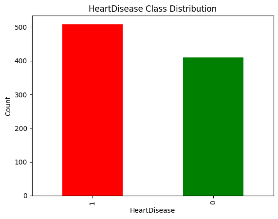

```python
df = pd.read_csv("heart.csv")

print("Dataset shape:", df.shape)
print(df.head())

class_counts = df['HeartDisease'].value_counts()
print("\nClass Distribution:\n", class_counts)


class_counts.plot(kind='bar', color=['red','green'])
plt.title("HeartDisease Class Distribution")
plt.xlabel("HeartDisease")
plt.ylabel("Count")
plt.show()
```

```python
def stratified_split(df, target_col, seed=42):
    np.random.seed(seed)
    train_df, val_df, test_df = [], [], []

    for cls, subset in df.groupby(target_col):
        subset = subset.sample(frac=1, random_state=seed)
        n = len(subset)
        n_train = int(0.7 * n)
        n_val = int(0.15 * n) # taking only n_val to avoid rounding issues

        train_df.append(subset.iloc[:n_train])
        val_df.append(subset.iloc[n_train:n_train+n_val])
        test_df.append(subset.iloc[n_train+n_val:])

    train_df = pd.concat(train_df)
    val_df = pd.concat(val_df)
    test_df = pd.concat(test_df)
    return train_df, val_df, test_df


#train_df, val_df, test_df = stratified_split(df, "HeartDisease", seed=42)
```

```python
categorical_cols = df.select_dtypes(include='object').columns
df_numeric = pd.get_dummies(df, columns=categorical_cols, drop_first=True)

train_df, val_df, test_df = stratified_split(df_numeric, "HeartDisease", seed=42)
```

| HeartDisease | Train | Validation | Test |
| --- | --- | --- | --- |
| 0 | 287 | 61 | 62 |
| 1 | 355 | 76 | 77 |

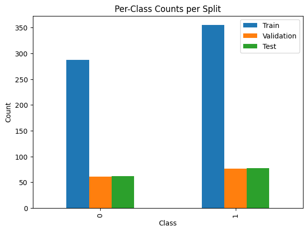

```python
# Showing per-class counts
def class_table(df_list, names):
    counts = [d["HeartDisease"].value_counts().sort_index() for d in df_list]
    return pd.DataFrame(counts, index=names).T.fillna(0).astype(int)

split_table = class_table([train_df, val_df, test_df], ["Train", "Validation", "Test"])
display(split_table)


split_table.plot(kind='bar', figsize=(7,5))
plt.title("Per-Class Counts per Split")
plt.ylabel("Count")
plt.xlabel("Class")
plt.grid(False)
plt.show()
```

```python
class NaiveBayes:
    def __init__(self, epsilon=1e-6):
        self.epsilon = epsilon
        self.classes = None
        self.log_prior = {}
        self.mean = {}
        self.var = {}


    def fit(self, X, y):
        """Compute priors and likelihoods in log-space."""
        X = np.asarray(X, dtype=np.float64)  # force numeric array..due to ValueError and attributeErrors lol
        y = np.asarray(y)
        self.classes = np.unique(y)
        self._calculate_prior(y)
        self._calculate_likelihood(X, y)



    def _calculate_prior(self, y):
        """Return log-priors for each class."""
        n_samples = len(y)
        self.log_prior = {cls: np.log(np.sum(y == cls) / n_samples) for cls in self.classes}



    def _calculate_likelihood(self, X, y):
        """Return log-likelihood parameters (mean, var for Gaussian NB)."""
        for cls in self.classes:
            X_c = X[y == cls]
            self.mean[cls] = np.array(X_c.mean(axis=0), dtype=np.float64)
            self.var[cls] = np.array(X_c.var(axis=0), dtype=np.float64) + self.epsilon

    def _log_probability(self, x, cls):
        """Compute log P(class|x) using priors + likelihoods."""
        x = np.asarray(x, dtype=np.float64)
        mean = self.mean[cls]
        var = self.var[cls]
        log_likelihood = -0.5 * np.sum(np.log(2 * np.pi * var))
        log_likelihood -= 0.5 * np.sum((x - mean)**2 / var)
        return self.log_prior[cls] + log_likelihood

    def predict(self, X):
        """Predict class labels for samples."""
        X = np.asarray(X, dtype=np.float64)
        y_pred = []
        for i in range(X.shape[0]):
            log_probs = [self._log_probability(X[i], cls) for cls in self.classes]
            y_pred.append(self.classes[np.argmax(log_probs)])
        return np.array(y_pred)
```

```python
display(split_table)
```

| HeartDisease | Train | Validation | Test |
| --- | --- | --- | --- |
| 0 | 287 | 61 | 62 |
| 1 | 355 | 76 | 77 |

```
Metrics on Train, Validation, Test:
            Accuracy  Precision    Recall
Train       0.806854   0.823529  0.828169
Validation  0.795620   0.863636  0.750000
Test        0.863309   0.881579  0.870130
```

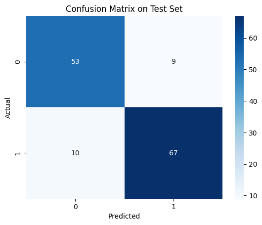

```python
splits = {
    "Train": (train_df.drop(columns='HeartDisease').values, train_df['HeartDisease'].values),
    "Validation": (val_df.drop(columns='HeartDisease').values, val_df['HeartDisease'].values),
    "Test": (test_df.drop(columns='HeartDisease').values, test_df['HeartDisease'].values)
}
nb = NaiveBayes(epsilon=1)
X_train, y_train = splits["Train"]
nb.fit(X_train, y_train)
results = {}
for name, (X, y) in splits.items():
    y_pred = nb.predict(X)
    results[name] = {
        "Accuracy": accuracy_score(y, y_pred),
        "Precision": precision_score(y, y_pred),
        "Recall": recall_score(y, y_pred)
    }


metrics_table = pd.DataFrame(results).T
print("\nMetrics on Train, Validation, Test:")
print(metrics_table)

y_test_pred = nb.predict(splits["Test"][0])
cm = confusion_matrix(splits["Test"][1], y_test_pred)
sns.heatmap(cm, annot=True, fmt='d', cmap='Blues', xticklabels=[0,1], yticklabels=[0,1])
plt.xlabel("Predicted")
plt.ylabel("Actual")
plt.title("Confusion Matrix on Test Set")
plt.show()
```

```
Test Accuracy: 0.9137
Precision: 0.9221
Recall: 0.9221
```

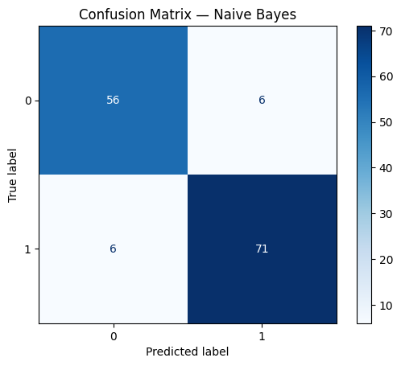

```python
# Training on train + validation
X_combined = np.vstack([X_train, X_val])
y_combined = np.hstack([y_train, y_val])

nb_model = NaiveBayes(epsilon=1e-6)
nb_model.fit(X_combined, y_combined)


y_pred_test = nb_model.predict(X_test)


acc = accuracy_score(y_test, y_pred_test)
prec = precision_score(y_test, y_pred_test)
rec = recall_score(y_test, y_pred_test)

print(f"Test Accuracy: {acc:.4f}")
print(f"Precision: {prec:.4f}")
print(f"Recall: {rec:.4f}")


cm = confusion_matrix(y_test, y_pred_test)
ConfusionMatrixDisplay(cm, display_labels=[0,1]).plot(cmap='Blues')
plt.title("Confusion Matrix — Naive Bayes")
plt.show()
```

K-Means on the Iris Dataset

**Dataset:** `sklearn.datasets.load_iris()` (150 samples, 4 numeric features: sepal length, sepal width, petal length, petal width) **Goal:** Explore unsupervised clustering with K-Means, find the best number of clusters, and interpret results.

**Allowed Libraries:** `numpy`, `pandas`, `matplotlib`, `seaborn`, `sklearn.metrics`, `sklearn.preprocessing.StandardScaler` **Seed:** 42 everywhere

## 🔹 Step 1 — Load & Explore

- Load the Iris dataset.
- Print dataset shape and first 5 rows.
- Show feature descriptions.
- Show **class distribution** (for reference — but labels will not be used in clustering).
- Standardize features (mean = 0, std = 1).

**Deliverable:** 📊 Data preview + standardized features

## 🔹 Step 2 — Choose K using Elbow Method

- Run **K-Means** for K = 2…8.
- Record **within-cluster sum of squares (WCSS)** = Inertia.

**Equation (WCSS):** [ WCSS = \sum_{i=1}^k \sum_{x \in C_i} ||x - \mu_i||^2 ]

- Plot **Elbow Curve** (K vs inertia).

**Question:** 👉 Where is the “elbow”? Which K looks most appropriate?

## 🔹 Step 3 — Evaluate Clustering Quality

- For each K (2…8), compute **silhouette score**.

**Equation (Silhouette):** [ s = \frac{b - a}{\max(a, b)} ] where:

- (a) = mean intra-cluster distance (cohesion)
- (b) = mean nearest-cluster distance (separation)
- Plot **Silhouette Score vs K**.

**Question:** 👉 Does this confirm your elbow choice? Why or why not?

## 🔹 Step 4 — Visualize Clusters

- Create 2D scatterplot using **petal length vs petal width**.

## 🔹 Step 6 — Reflection

- Why does **K-Means struggle** to perfectly match the 3 true species?
- Would K-Means work well if clusters were **not spherical**? Why or why not?

```python
import pandas as pd
import matplotlib.pyplot as plt
import seaborn as sns
from sklearn.datasets import load_iris
from sklearn.preprocessing import StandardScaler
#from sklearn.metrics import silhouette_score
import numpy as np
np.random.seed(42)
```

```python
iris = load_iris()
X = iris.data
y = iris.target

print("Shape:", X.shape)

print("\nFirst 5 rows:")
print(pd.DataFrame(X, columns = iris.feature_names).head())



print("\nFeatures:", iris.feature_names)



print("\nClass distribution:")
print(pd.Series(y).value_counts())

# Standardization
scaler = StandardScaler()
X_scaled = scaler.fit_transform(X)
```

```
Shape: (150, 4)

First 5 rows:
   sepal length (cm)  sepal width (cm)  petal length (cm)  petal width (cm)
0                5.1               3.5                1.4               0.2
1                4.9               3.0                1.4               0.2
2                4.7               3.2                1.3               0.2
3                4.6               3.1                1.5               0.2
4                5.0               3.6                1.4               0.2

Features: ['sepal length (cm)', 'sepal width (cm)', 'petal length (cm)', 'petal width (cm)']

Class distribution:
0    50
1    50
2    50
Name: count, dtype: int64
```

```python
import numpy as np

class KMeansFromScratch:
    def __init__(self, n_clusters=3, max_iter=300, tol=1e-4, random_state=42):
        self.n_clusters = n_clusters
        self.max_iter = max_iter
        self.tol = tol
        self.random_state = random_state
        self.centroids = None
        self.labels_ = None
        self.inertia_ = None

    def fit(self, X):
        """
        Fit KMeans model to data X.
        Steps:
        1. Initialize centroids randomly
        2. Repeat until convergence or max_iter:
           - Assign each point to nearest centroid
           - Update centroids as mean of assigned points
           - Compute inertia (WCSS)
        """
        np.random.seed(self.random_state)
        self._initialize_centroids(X)

        for i in range(self.max_iter):
            labels = self._assign_clusters(X)
            new_centroids = self._update_centroids(X, labels)
            diff = np.linalg.norm(self.centroids - new_centroids)
            self.centroids = new_centroids

            if diff < self.tol:
                break


        self.labels_ = self._assign_clusters(X)
        self.inertia_ = self._compute_inertia(X, self.labels_)

    def _initialize_centroids(self, X):
        """
        Pick initial centroids from X (randomly or k-means++).
        """
        idx = np.random.choice(X.shape[0], self.n_clusters, replace=False)
        self.centroids = X[idx]

    def _assign_clusters(self, X):
        """
        Assign each data point to the closest centroid.
        Returns: array of cluster labels
        """
        distances = np.linalg.norm(X[:, np.newaxis] - self.centroids, axis=2)

        return np.argmin(distances, axis=1)

    def _update_centroids(self, X, labels):
        """
        Compute new centroids as mean of assigned points.
        """

        centroids = np.zeros((self.n_clusters, X.shape[1]))
        for k in range(self.n_clusters):
            points = X[labels == k]
            if len(points) > 0:
                centroids[k] = points.mean(axis=0)
            else:

                centroids[k] = X[np.random.randint(0, X.shape[0])]
        return centroids

    def _compute_inertia(self, X, labels):
        """
        Compute WCSS (within-cluster sum of squares).
        """

        inertia = 0
        for k in range(self.n_clusters):
            points = X[labels == k]
            inertia += ((points - self.centroids[k])**2).sum()
        return inertia

    def predict(self, X):
        """
        Assign clusters for new unseen data based on nearest centroid.
        """

        distances = np.linalg.norm(X[:, np.newaxis] - self.centroids, axis=2)
        return np.argmin(distances, axis=1)
```

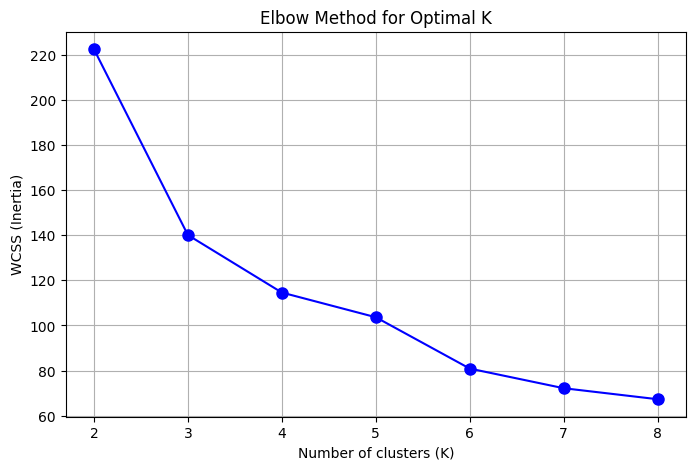

```python
# Range of the K values
K_range = range(2, 9)
wcss = []

# Computing WCSS for each K
for k in K_range:
    kmeans = KMeansFromScratch(n_clusters=k)
    kmeans.fit(X_scaled)
    wcss.append(kmeans.inertia_)

# Plotting Elbow Curve
plt.figure(figsize=(8,5))
plt.plot(K_range, wcss, 'bo-', markersize=8)
plt.xlabel('Number of clusters (K)')
plt.ylabel('WCSS (Inertia)')
plt.title('Elbow Method for Optimal K')
plt.xticks(K_range)
plt.grid(True)
plt.show()
```

**ELBOW**

The WCSS drops sharply from K = 2 to K = 3 afterwards then the rate of decrease slows down. This means that our sharp bend (elbow) is the most approriate number of clusters which also makes sense if we factor in the fact that the iris dataset has 3 species.

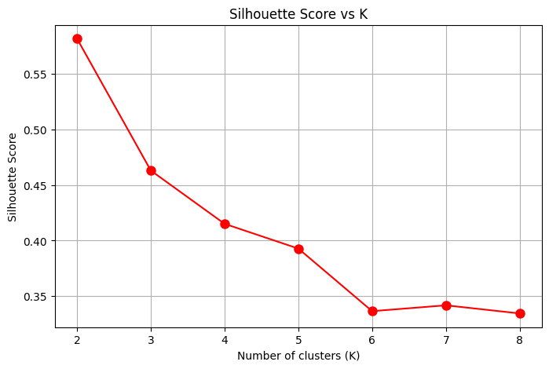

```python
def manual_silhouette_score_np(X, labels):
    n_samples = X.shape[0]
    unique_labels = np.unique(labels)
    s_list = np.zeros(n_samples)

    for i in range(n_samples):
        own_cluster = labels[i]
        own_mask = labels == own_cluster
        other_mask = labels != own_cluster

        # a_i: intra-cluster distance (cohesion)
        same_cluster_points = X[own_mask]
        if same_cluster_points.shape[0] == 1:
            a_i = 0
        else:

            diffs = same_cluster_points - X[i]
            dists = np.linalg.norm(diffs, axis=1)

            a_i = np.sum(dists) / (len(dists) - 1)

        # b_i: nearest-cluster distance (separation)
        b_list = []
        for other_label in unique_labels:
            if other_label == own_cluster:
                continue
            other_points = X[labels == other_label]
            diffs = other_points - X[i]
            dists = np.linalg.norm(diffs, axis=1)
            b_list.append(np.mean(dists))
        b_i = min(b_list)

        # silhouette for point i
        s_list[i] = (b_i - a_i) / max(a_i, b_i) if max(a_i, b_i) != 0 else 0

    return np.mean(s_list)



sil_scores_manual = []
K_range = range(2, 9)

for k in K_range:
    kmeans = KMeansFromScratch(n_clusters=k)
    kmeans.fit(X_scaled)
    score = manual_silhouette_score_np(X_scaled, kmeans.labels_)
    sil_scores_manual.append(score)


plt.figure(figsize=(8,5))
plt.plot(K_range, sil_scores_manual, 'ro-', markersize=8)
plt.xlabel('Number of clusters (K)')
plt.ylabel('Silhouette Score')
plt.title('Silhouette Score vs K')
plt.xticks(K_range)
plt.grid(True)
plt.show()
```

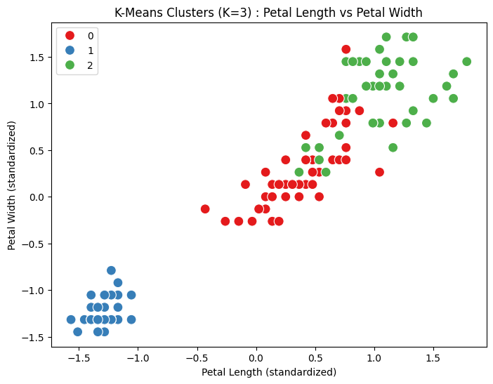

```python
kmeans_final = KMeansFromScratch(n_clusters=3)
kmeans_final.fit(X_scaled)
labels = kmeans_final.labels_

plt.figure(figsize=(8,6))
sns.scatterplot(x=X_scaled[:,2], y=X_scaled[:,3], hue=labels, palette='Set1', s=100)
plt.xlabel('Petal Length (standardized)')
plt.ylabel('Petal Width (standardized)')
plt.title('K-Means Clusters (K=3) : Petal Length vs Petal Width')
plt.show()
```

### REFLECTION

*Why K-Means struggles with true species?* The K-Means assumes spherical and equal sized clusters, but from the graph, we can see that iris species have overlapping distribution in some of its features. Due to this, some points might not be clustered properly (potentially).

*Would K-Means work well if clusters were not spherical?* No, not neccsarily, the K-Means minimizes the euclidean distance to centroids so non-spherical clusters might be split incorrectly.